# Лабораторная работа №2

Простые сети в GNS3.Анализ трафика

Устинова В. В.

Российский университет дружбы народов, Москва, Россия

26 сентября 2026

# Информация

## Докладчик

- Устинова Виктория Вадимовна
- студент НПИбд-01-24
- Российский университет дружбы народов

## Цель работы

Построение простейших моделей сети на базе коммутатора и маршрутизаторов FRR и VyOS в GNS3, анализ трафика посредством Wireshark.

## Задание

1. Построить в GNS3 топологию сети, состоящей из коммутатора Ethernet и двух оконечных устройств (персональных компьютеров).
2. Задать оконечным устройствам IP-адреса в сети 192.168.1.0/24. Проверить связь.
3. С помощью Wireshark захватить и проанализировать ARP-сообщения.
4. С помощью Wireshark захватить и проанализировать ICMP-сообщения.
5. Построить в GNS3 топологию сети, состоящей из маршрутизатора FRR, коммутатора Ethernet и оконечного устройства.
6. Задать оконечному устройству IP-адрес в сети 192.168.1.0/24.
7. Присвоить интерфейсу маршрутизатора адрес 192.168.1.1/24
8. Проверить связь. . Построить в GNS3 топологию сети, состоящей из маршрутизатора VyOS, коммутатора Ethernet и оконечного устройства.
9. Задать оконечному устройству IP-адрес в сети 192.168.1.0/24.
10. Присвоить интерфейсу маршрутизатора адрес 192.168.1.1/24
11. Проверить связь.

## Выполнение лабораторной работы

Построить в GNSS3 топологию сети , состоящей из коммутатора Ethernet и двух оконечных устройств VPCS соеденить VPCS с куммутатором и отобразить обозначения интерфейсов

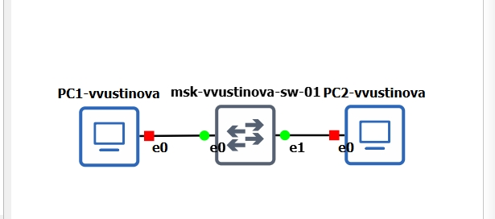

В рабочей области рзмещены PC1-vvustinova, коммутатор msk-vvustinova-sw-01 и PC2-vvustinova соединенные через интерфейсы e0 and e1

## Выполнение лабораторной работы

Просмотреть синтаксис возможных для ввода команд VPCS, набрав /?. Задать IP-адрес первому узлу

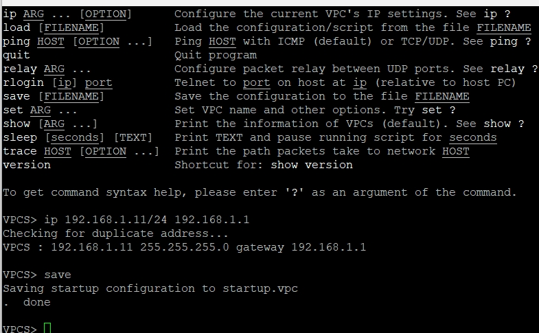

Выведена справка по командам VPCS, выполнен ip 192.168.1.11/24 192.168.1.1 и save.

## Выполнение лабораторной работы

Задать IP-адрес второму VPCS в сети 192.168.1.0/24

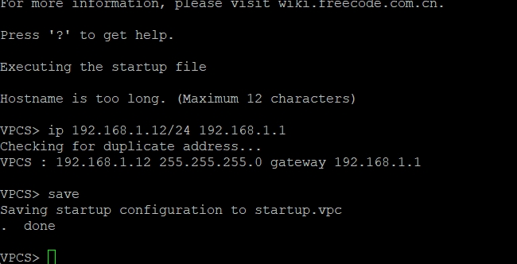

Выполнена команда ip 192.168.1.12/24 192.168.1.1, адрес сохранён командой save.

## Выполнение лабораторной работы

Проверить связь между оконечными устройствами с помощью команды ping

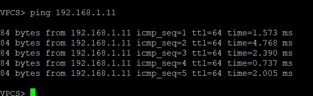

## Выполнение лабораторной работы

Включить захват трафика на соединении между PC1 и коммутатором и проанализировать полученную информацию в Wireshark.

[figure not shown]

В Wireshark видны пакеты Router Solicitation (ICMPv6) и Gratuitous ARP для адресов 192.168.1.11 и 192.168.1.12.

## Выполнение лабораторной работы

Выполнить ping с опцией -1 (ICMP) для проверки связи.

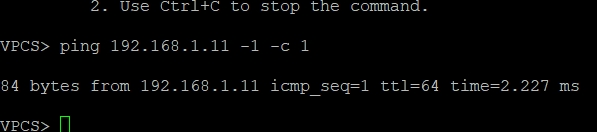

Выполнена команда ping 192.168.1.11 -1 -c 1, получен ответ за 2.227 мс.

## Выполнение лабораторной работы

Проанализировать в Wireshark пакеты ARP и ICMP при ping-запросе

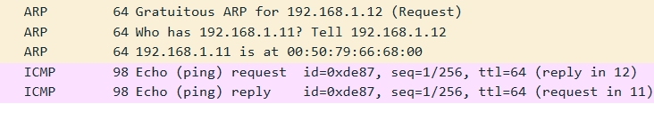

Видны ARP-запросы и ICMP Echo request/reply между узлами 192.168.1.11 и 192.168.1.12..

## Выполнение лабораторной работы

Выполнить ping с опцией -2 (UDP) для проверки связи

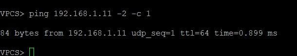

Выполнена команда ping 192.168.1.11 -2 -c 1, получен ответ за 0.899 мс.

## Выполнение лабораторной работы

Выполнить ping с опцией -3 (TCP) для проверки связи и проанализировать TCP-сессию.

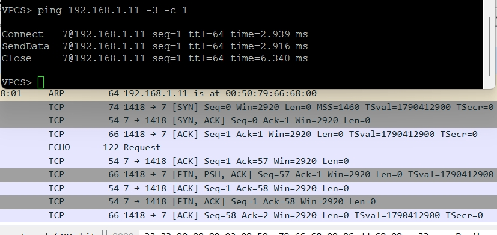

Выполнена команда ping 192.168.1.11 -3 -c 1, в Wireshark видны этапы SYN, SYN-ACK, ACK, ECHO, FIN..

## Выполнение лабораторной работы

Построить в GNS3 топологию сети, состоящей из VPCS, коммутатора Ethernet и маршрутизатора FRR. Присвоить устройствам имена по заданному шаблон

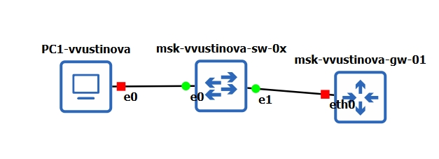

В рабочей области размещены PC1-vvustinova, коммутатор msk-vvustinova-sw-0x и маршрутизатор msk-vvustinova-gw-01.

## Выполнение лабораторной работы

Hастроить IP-адресацию для интерфейса узла PC1 и проверить её командой show ip

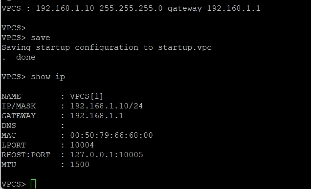

Показаны IP-адрес 192.168.1.10/24, шлюз 192.168.1.1 и MAC-адрес 00:50:79:66:68:00.

## Выполнение лабораторной работы

Настроить маршрутизатор FRR: задать hostname msk-vvustinova-gw-01, назначить интерфейсу eth0 адрес 192.168.1.1/24, сохранить конфигурацию

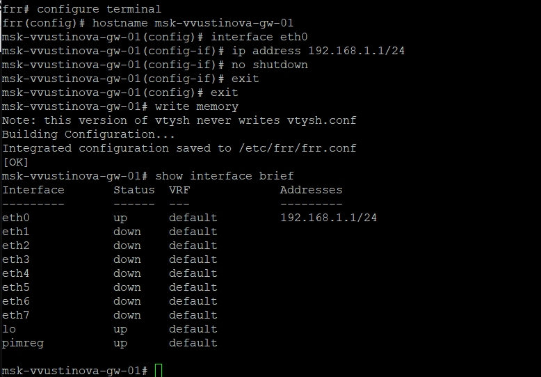

Выполнены команды configure terminal, hostname, interface eth0, ip address, no shutdown, write memory. Показан вывод show interface brief.

## Выполнение лабораторной работы

Проанализировать в Wireshark ICMP-пакеты при ping между узлом и маршрутизатором

[figure not shown]

Видны ICMP Echo request и reply между 192.168.1.10 и 192.168.1.1, а также ARP-запросы.

## Выполнение лабораторной работы

Проверить подключение: узел PC1 должен успешно отправлять эхо-запросы на адрес маршрутизатора 192.168.1.1. Также требовалось построить топологию с маршрутизатором VyOS и настроить его интерфейс eth0.

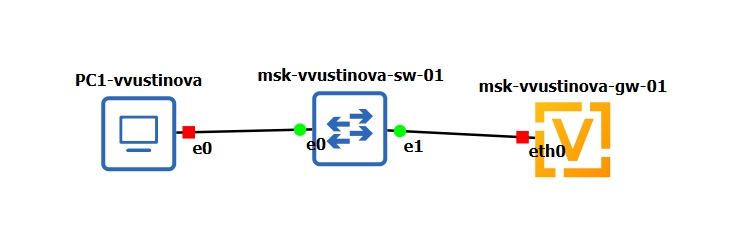

## Выводы

В ходе работы были построены простейшие модели сети на базе коммутатора и маршрутизатора FRR в GNS3. Освоены настройка IP-адресации на VPCS и маршрутизаторе FRR, проверка связи с помощью утилиты ping. Проведён анализ трафика в Wireshark: изучены ARP-запросы, ICMP-, UDP- и TCP-пакеты. Попытка развернуть маршрутизатор VyOS не удалась из-за нехватки ресурсов компьютера, однако принципы настройки VyOS были изучены теоретически.